# Predicting the mutations generated by repair of Cas9-induced double-strand breaks

Felicity Allen, ... Leopold Parts

- Wellcome Sanger Institute, Hinxton, UK.
- Cambridge Institute of Medical Research, University of Cambridge, Cambridge, UK.
- Wellcome/Cancer Research UK
- Gurdon Institute, University of Cambridge, Cambridge, UK. - - Department of Biochemistry, University of Cambridge, Cambridge, UK.
- UK Dementia Research Institute, Cambridge, UK.
- Department of Computer Science, University of Tartu, Tartu, Estonia.

## Why

Not all gRNAs are created equal. Just because 2 guides each exactly match their targets doesn't mean the edits they generate will be the same. This paper looks to explore and predict these differences. For human gene-editting this will be required to ensure the induced edits are precise and minimal. In our HIV use-case we would like to make the maximal edits.

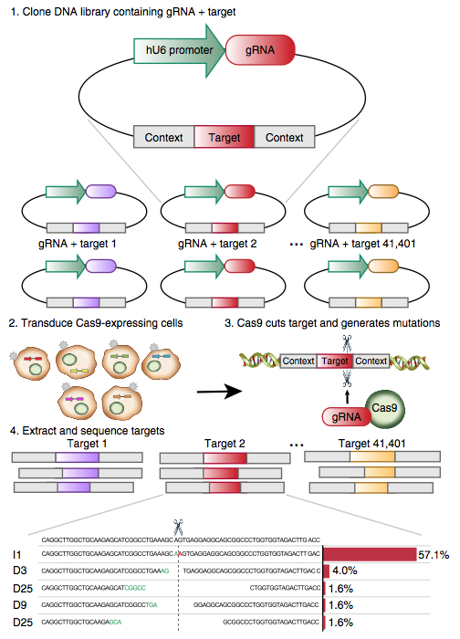

```python
WImage(filename='Fig1.png', resolution=300)
```

## Question 1:

Are the edits consistent and do edits on the plasmid match edits on endogenous DNA?

## Experimental Info

- K562 human chronic myelogenous leukemia cell line.
- Total of 41,630 constructs.
- We delivered these into cells using lentiviral infection at 0.5–0.6 multiplicity.
- Cultured for 7 d to ensure saturated editing

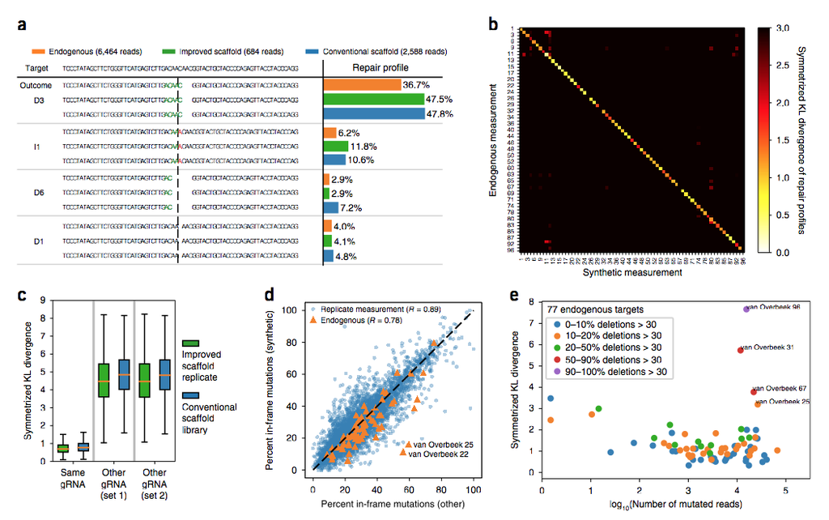

```python
img = WImage(filename='Fig2.png', resolution=300)
img
```

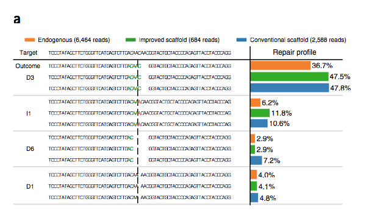

```python
img = WImage(filename='Fig2.png', resolution=300)
img.crop(left = 0, top = 0, width = 600, height = 350)
img
```

Example editing profile.

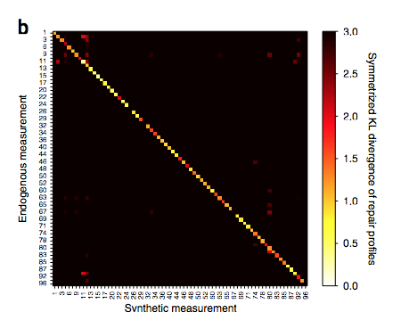

```python
img = WImage(filename='Fig2.png', resolution=300)
img.crop(left = 600, top = 0, width = 450, height = 350)
img
```

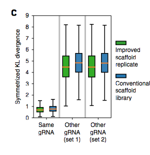

```python
img = WImage(filename='Fig2.png', resolution=300)
img.crop(left = 0, top = 350, width = 300, height = 350)
img
```

Edits from the same gRNA are more similar than edits from different gRNAs. This goes torwards reproducibility (how often does the same gRNA produce the same edits) as well as determinism (there must be something about the gRNA that is controlling the edits).

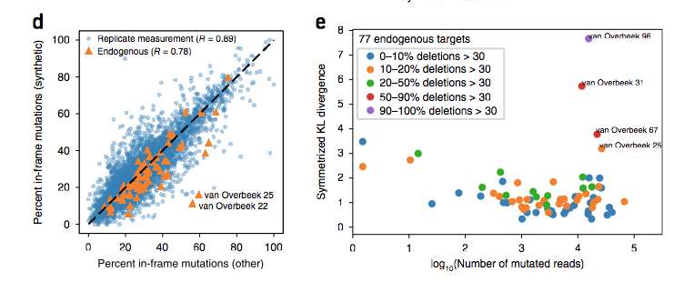

```python
img = WImage(filename='Fig2.png', resolution=300)
img.crop(left = 300, top = 350, width = 900, height = 350)
img
```

## Question 2

What type of edits does spCas9 produce?

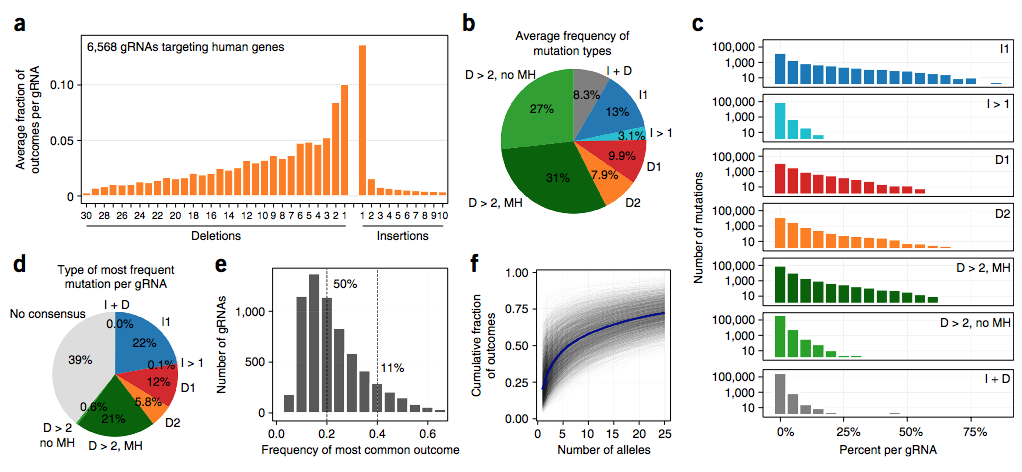

```python
img = WImage(filename='Fig3.png', resolution=300)
#img.crop(left = 300, top = 350, width = 900, height = 350)
img
```

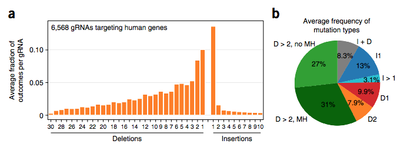

```python
img = WImage(filename='Fig3.png', resolution=300)
img.crop(left = 0, top = 0, width = 675, height = 250)
img
```

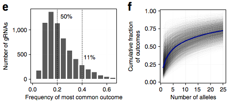

```python
img = WImage(filename='Fig3.png', resolution=300)
img.crop(left = 210, top = 250, width = 475, height = 250)
img
```

## Question 3

Does the sequence of the target influence the distribution of edits?

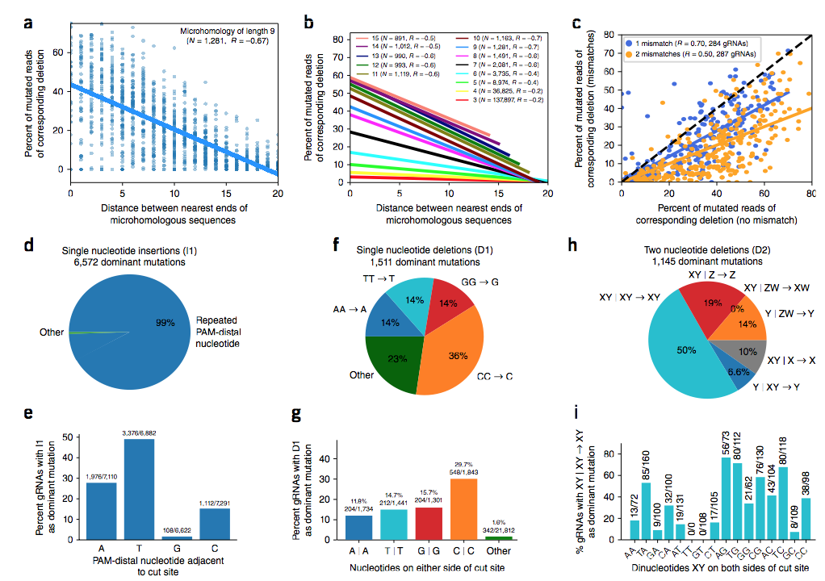

```python
img = WImage(filename='Fig4.png', resolution=300)
#img.crop(left = 210, top = 250, width = 475, height = 250)
img
```

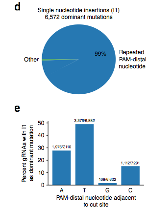

```python
img = WImage(filename='Fig4.png', resolution=300)
img.crop(left = 0, top = 290, width = 300, height = 600)
img
```

This is a look at what the edits actually are. Here is what happens in single basepair insertions. We see that the inserted base is almost always the PAM-distal base ... the *`N`* in `NGG`.

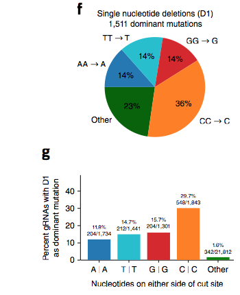

```python
img = WImage(filename='Fig4.png', resolution=300)
img.crop(left = 300, top = 290, width = 350, height = 600)
img
```

From **F)** and **G)** we see that single nucleotide deletions tend to be removals of di-nucleotide pairs.

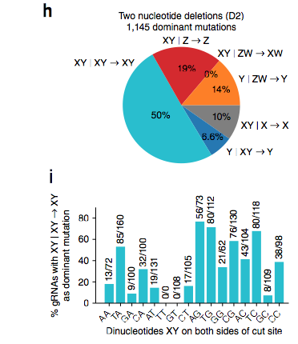

```python
img = WImage(filename='Fig4.png', resolution=300)
img.crop(left = 650, top = 290, width = 400, height = 600)
img
```

From **H)** and **I)** we see that di-nucleotide deletions tend to be removals of pairs of di-nucleotides.

## Question 4

Do different cell lines have different editing profiles? Do different Cas9s have different editing profiles?

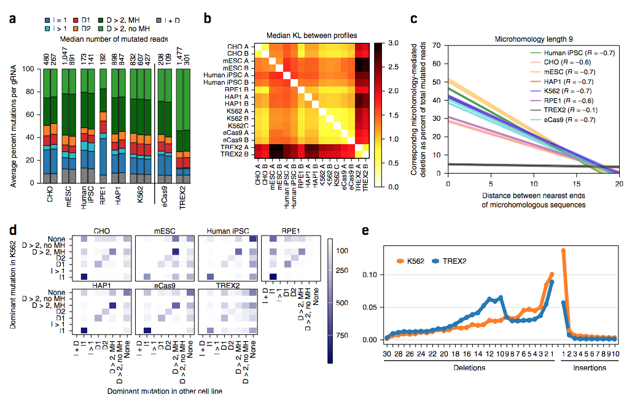

```python
img = WImage(filename='Fig5.png', resolution=300)
img
```

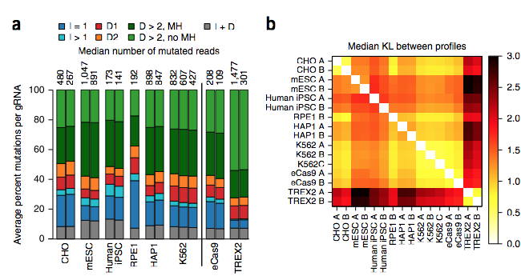

```python
img = WImage(filename='Fig5.png', resolution=300)
img.crop(left = 0, top = 0, width = 650, height = 350)
img
```

Here we're looking at the editting in different cell lines. The important thing to note here; these are still "plasmid" edits. So these differences aren't due to chromatin. The right-most two samples `eCas9` and `TREX2` are modified *spCas9* s. **A)** shows us that the overall editing profile across the 3777 gRNAs is the consistent. **B)** shows a few things. The `TREX` Cas9 produces different profiles relative to an unedited Cas. Meanwhile, `eCas9` has a consistent profile relative to an unedited Cas.

> Some relative changes of preferred mutation classes were notable. **Large insertions occurred more frequently in stem cells, with 2.6-fold and 1.7-fold increases in human iPSCs and mESCs, respectively, over K562 levels *[Emphasis added]***. However, the frequency of these mutations remained low and non-reproducible (Supplementary Fig. 15), which also explains the increase in overall between-replicate divergence (Fig. 5b).

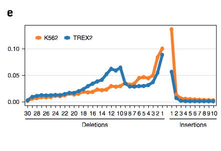

```python
img = WImage(filename='Fig5.png', resolution=300)
img.crop(left = 575, top = 350, width = 650)
img
```

`TREX` Cas9 has a different editing profile relative to the standard spCas9. This shows that it has a higher likelihood of longer deletions and lower likelihoods of single-bp insertions.

## Question 5

Can we predict the edits given the target?

They use a logistic regression model with custom features.

> For each gRNA–target pair we generated candidate indels by considering all possible insertions up to size 2 within 3 nucleotides of the cut site, and all deletions spanning the cut site with a left edge from position 1 to the right of the cut site to up to 30 nucleotides left of the cut site and a right edge up to 30 nucleotides the other way, up to a maximum deletion size of 30. For each of these candidates, we computed a set of 3,633 binary features that describe the length, location and nucleotide composition of inserted sequences, microhomologies and their neighboring nucleotides. Many of these features also comprise pairwise ‘AND’ results between features to capture interaction effects.

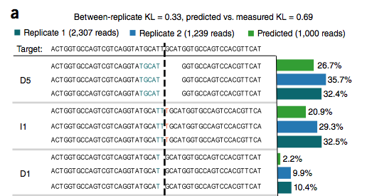

```python
img = WImage(filename='Fig6.png', resolution=300)
img.crop(height = 275)
img
```

An example of the editting and its prediction.

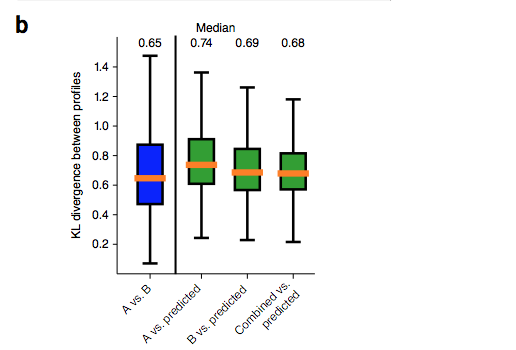

```python
img = WImage(filename='Fig6.png', resolution=300)
img.crop(top=275, height = 350)
img
```

This is a metric of how accurate thier predictions can be. The left-most is their inter-sample error ... the theoretical mimumum on their metric. This shows that their predictions are very close to their observed edits.

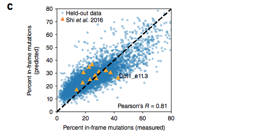

```python
img = WImage(filename='Fig6.png', resolution=300)
img.crop(top=625, height = 350)
img
```

Here they're using the "frameshift" prediction method to compare the observed vs predicted edit profiles. This was all done on held-out data.

## Conclusion

The authors were able to show numerous things about spCas9 editing:

- Replicates of editing the same target show similar editing profiles.
- Most gRNAs induce at least 10-15 edits.
- The most common edit in each profile only accounts for ~20-30% of the induced edits.
- Single bp insertions are likely the `N` of `NGG`.
- Deletions tend to remove duplicated bases or duplicated di-nucleotides.
- Different cell lines have slightly different editing profiles ... this is independent of chromatin.
- Editing can be predicted to within the error of the assay.
- The `eCas9` creates similar edit profiles, the `TREX` Cas9 produces vastly different editing profiles.